[figure not shown]

# **Análisis de Humedad en los procesos de Peletizado y Extrusión**

#### Unidad de nutrición animal de la empresa Gradezco Ltda

### **Introducción**

El presente informe se desarrolló mediante la plataforma Okuo Flow, una herramienta enfocada en la **centralización**, **integración** y **transformación** de datos asociados a la producción y la calidad en plantas de concentrados. Gracias a esta plataforma, es posible extraer información valiosa que facilita la toma de decisiones, al analizar de manera simultánea variables de producción (toneladas procesadas, tiempos de producción y sack-off) y de calidad (temperatura, durabilidad del pellet y humedad). Esto permite **optimizar el rendimiento** a la vez que se mantienen altos estándares de calidad, reducciendo la tensión entre los departamentos de producción y calidad, logrando un proceso más fluido y eficaz.  
En este contexto, usaremos Okuo Flow para dar un entendimiento estadísticos de los diferentes parámetros medidos en Unidad de nutrición animal de la empresa Gradezco Ltda.

### **Mediciones en Extrusión y Peletizado**

En los procesos de extrusión y peletizado se registran las mediciones totales o promedios del **%Sackoff**, **%Durabilidad**, **Actividad de Agua (AW)** y **Porcentaje de Humedad** tanto al inicio como al final de cada etapa, así como de **Temperatura** y **Carga**. A continuación se presenta la tabla con estos datos, segmentando cada proceso por máquina de trabajo:

| Maquina Empleada | Adiflow | Ton Iniciales | Ton Finales | Sackoff (%) | AW Prom | Hum Inicial Prom (%) | Hum Final Prom (%) | Temp Prom (°C) | Presion Prom (Psi) | Carga Prom (Puntos) | Durabilidad Prom (%) |
| --- | --- | --- | --- | --- | --- | --- | --- | --- | --- | --- | --- |
| Pelet 1 | Con Adiflow | 1394.272 | 1394.274 | 0.00 | 0.66 | 9.81 | 11.10 | 68.90 | 44.21 | 20.35 | 95.3 |
| Pelet 1 | Sin Adiflow | 598.798 | 593.870 | -0.82 | 0.65 | 9.58 | 10.70 | 65.80 | 26.18 | 16.10 | 95.0 |
| Pelet 2 y 3 | Con Adiflow | 1656.372 | 1645.097 | -0.68 | 0.66 | 9.93 | 11.17 | 68.17 | 63.91 | 11.79 | 95.3 |
| Pelet 2 y 3 | Sin Adiflow | 254.198 | 251.920 | -0.90 | 0.65 | 9.73 | 10.81 | 70.89 | 28.70 | 9.81 | 95.4 |
| Pelet 4 | Con Adiflow | 1059.584 | 1059.164 | -0.04 | 0.67 | 10.89 | 11.09 | 67.65 | 44.17 | 9.10 | 95.0 |
| Pelet 4 | Sin Adiflow | 267.096 | 265.400 | -0.63 | 0.65 | 9.86 | 11.04 | 69.34 | 28.17 | 6.97 | 93.8 |

| Maquina Empleada | Adiflow | Ton Iniciales | Ton Finales | Sackoff (%) | AW Prom (%) | Hum Inicial Prom (%) | Hum Final Prom (%) |
| --- | --- | --- | --- | --- | --- | --- | --- |
| Extruder 1020 | Con Adiflow | 2208.269 | 2122.132 | -3.90 | 0.51 | 10.15 | 7.90 |
| Extruder 1020 | Sin Adiflow | 1173.861 | 1120.362 | -4.56 | 0.49 | 9.36 | 7.07 |
| Extruder 620 | Con Adiflow | 1121.109 | 1083.288 | -3.37 | 0.53 | 9.94 | 8.34 |
| Extruder 620 | Sin Adiflow | 54.900 | 52.460 | -4.44 | 0.53 | 9.37 | 7.95 |

### **Comparacción de Humedad en etapa inicial y final por procesos**

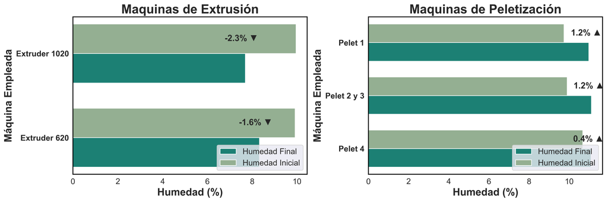

### **Comparacción de actividad de agua por maquinaria y Con/Sin adiflow**

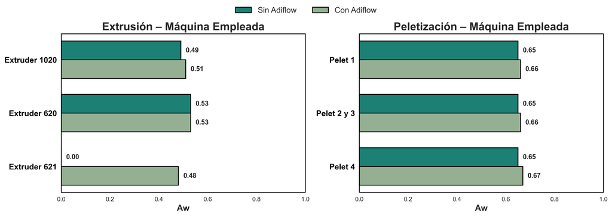

En extrusión la actividad de agua no supera el 0.6 y en peletizado la actividad de agua no supera el 0.7.

### **Comparacción de Sackoff por maquinaria y Con/Sin adiflow**

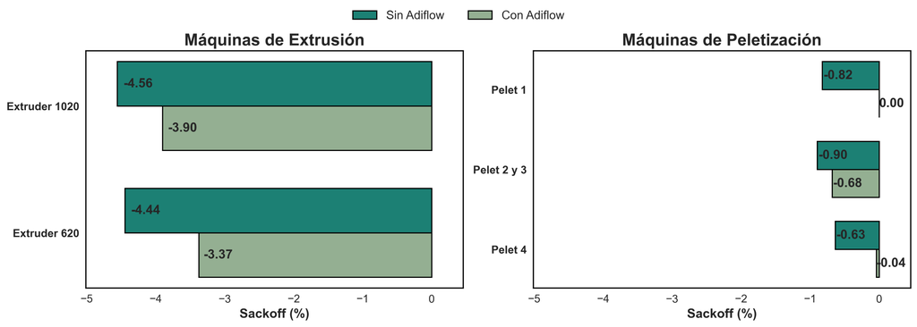

De forma sistematica, independiente del proceso, con adiflow se observa una mejora en el Sackoff.

### **Otras medididas en los procesos de peletización**

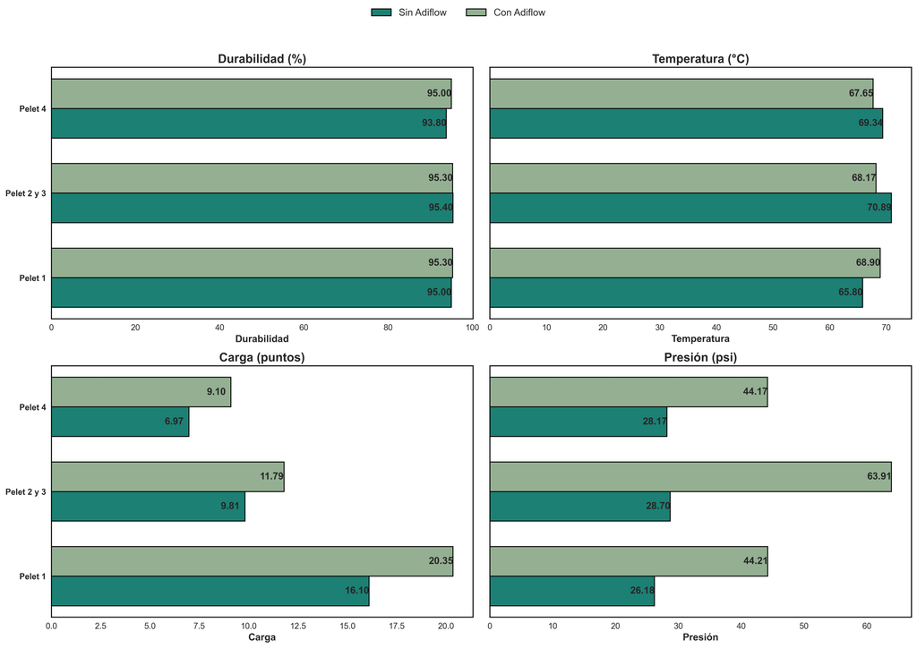

Se ha detectado una notable estabilidad en las mediciones de durabilidad y temperatura, independientemente de la máquina de peletización y si el proceso se realiza con o sin adiflow. En cambio, la carga y la presión presentan variación, existiendo una mayor carga y presión cuando las dietas a procesar se realizan con adiflow.

#### Fecha de elaboración: 26-12-2025

#### [okuo.bio](https://okuo.bio/)